# S&P 500 ESG Clustering

## Introduction

ESG stands for Environmental, Social, and Governance, which is a set of criteria that is used by investors to evaluate a companies performance and sustainability beyond financial metrics.

- Environmental: focus on company's impact on the planet
  - Climate risk
  - Energy use
  - Pollution
  - Waste
  - Resources
- Social: how a company manages its relationships with employees and the community
  - Employee relations
  - Community relations
  - Human rights
  - Customer satisfaction
- Governance: examines how a company is run
  - Leadership
  - Executive pay
  - Audits & controls
  - Shareholder rights
  - Transparency

This project will explore ESG performance of the S&P 500 companies through K-Means clustering, aiming to identify which sectors and industries fall into specific ESG risk clusters. By implementing and analyzing a clustering model, we can help investors see which areas of the market have historically high or low ESG and base their investments on those factors.

## What is Clustering?

Clustering is an unsupervised machine learning modeling technique that groups observations based on similarities. The goal of this method is to find natural groupings within a dataset without any prior knowledge / labels of the categories. In this project, I will be using K-Means clustering.

K-Means Clustering: create K amount of random center points (centroids). In the algorithm, data points are compared to the centroids. The algorithm tries to optimize placement for each centroid.

## The Data

The data used in this project is from [kaggle](https://www.kaggle.com/datasets/pritish509/s-and-p-500-esg-risk-ratings). This dataset provides a comprehensive overview of ESG performance of companies listed in the S&P 500. It provides key features such as Symbol, Name, Industry, Environmental Risk Score, Social Risk Score, Governance Risk Score, etc. In total, there are 15 key features in this dataset with over 500 rows.

```python
import numpy as np
import pandas as pd
import matplotlib.pyplot as plt
import seaborn as sns
```

```python
df = pd.read_csv("SP_500_ESG_Risk_Ratings.csv")
df
```

|  | Symbol | Name | Address | Sector | Industry | Full Time Employees | Description | Total ESG Risk score | Environment Risk Score | Governance Risk Score | Social Risk Score | Controversy Level | Controversy Score | ESG Risk Percentile | ESG Risk Level |
| --- | --- | --- | --- | --- | --- | --- | --- | --- | --- | --- | --- | --- | --- | --- | --- |
| 0 | ENPH | Enphase Energy, Inc. | 47281 Bayside Parkway\nFremont, CA 94538\nUnit... | Technology | Solar | 3,157 | Enphase Energy, Inc., together with its subsid... | NaN | NaN | NaN | NaN | NaN | NaN | NaN | NaN |
| 1 | EMN | Eastman Chemical Company | 200 South Wilcox Drive\nKingsport, TN 37662\nU... | Basic Materials | Specialty Chemicals | 14,000 | Eastman Chemical Company operates as a special... | 25.3 | 12.8 | 6.6 | 5.8 | Moderate Controversy Level | 2.0 | 50th percentile | Medium |
| 2 | DPZ | Domino's Pizza Inc. | 30 Frank Lloyd Wright Drive\nAnn Arbor, MI 481... | Consumer Cyclical | Restaurants | 6,500 | Domino's Pizza, Inc., through its subsidiaries... | 29.2 | 10.6 | 6.3 | 12.2 | Moderate Controversy Level | 2.0 | 66th percentile | Medium |
| 3 | DAY | Dayforce, Inc. | 3311 East Old Shakopee Road\nMinneapolis, MN 5... | Technology | Software - Application | 9,084 | Dayforce Inc., together with its subsidiaries,... | NaN | NaN | NaN | NaN | NaN | NaN | NaN | NaN |
| 4 | DVA | Davita Inc. | 2000 16th Street\nDenver, CO 80202\nUnited States | Healthcare | Medical Care Facilities | 70,000 | DaVita Inc. provides kidney dialysis services ... | 22.6 | 0.1 | 8.4 | 14.1 | Moderate Controversy Level | 2.0 | 38th percentile | Medium |
| ... | ... | ... | ... | ... | ... | ... | ... | ... | ... | ... | ... | ... | ... | ... | ... |
| 498 | ACN | Accenture Plc | 1 Grand Canal Square\nGrand Canal Harbour\nDub... | Technology | Information Technology Services | 742,000 | Accenture plc, a professional services company... | 9.8 | 0.8 | 4.4 | 4.6 | Moderate Controversy Level | 2.0 | 3rd percentile | Negligible |
| 499 | ABBV | Abbvie Inc. | 1 North Waukegan Road\nNorth Chicago, IL 60064... | Healthcare | Drug Manufacturers - General | 50,000 | AbbVie Inc. discovers, develops, manufactures,... | 29.9 | 2.4 | 10.4 | 17.2 | Significant Controversy Level | 3.0 | 69th percentile | Medium |
| 500 | ABT | Abbott Laboratories | 100 Abbott Park Road\nAbbott Park\nNorth Chica... | Healthcare | Medical Devices | 114,000 | Abbott Laboratories, together with its subsidi... | 24.8 | 2.3 | 8.3 | 14.2 | Significant Controversy Level | 3.0 | 48th percentile | Medium |
| 501 | AOS | A.O. Smith Corporation | 11270 West Park Place\nSuite 170 PO Box 245008... | Industrials | Specialty Industrial Machinery | 12,000 | A. O. Smith Corporation manufactures and marke... | 25.4 | 7.2 | 6.4 | 11.9 | Low Controversy Level | 1.0 | 51st percentile | Medium |
| 502 | MMM | 3m Company | 3M Center\nSaint Paul, MN 55144-1000\nUnited S... | Industrials | Conglomerates | 85,000 | 3M Company provides diversified technology ser... | 37.3 | 17.2 | 6.5 | 13.6 | Severe Controversy Level | 5.0 | 89th percentile | High |

503 rows × 15 columns

## Data Preprocessing

Before we create the clustering model for this project, we first need to clean the data. I will start by seeing the amount of null values that are present in the dataset.

```python
print(df.shape)
df.isna().sum()
```

```
(503, 15)
```

```
Symbol                      0
Name                        0
Address                     1
Sector                      1
Industry                    1
Full Time Employees         5
Description                 1
Total ESG Risk score       73
Environment Risk Score     73
Governance Risk Score      73
Social Risk Score          73
Controversy Level          73
Controversy Score         100
ESG Risk Percentile        73
ESG Risk Level             73
dtype: int64
```

From the output above, we can see that a lot of these columns have 73 missing entries in critical numerical values for this project. Since it is the same number over multiple columns, we can assume that there are 73 companies without ESG scores. Lets try dropping those first.

```python
df = df.dropna(subset=['Total ESG Risk score'])

print(df.shape)
df.isna().sum()
```

```
(430, 15)
```

```
Symbol                     0
Name                       0
Address                    0
Sector                     0
Industry                   0
Full Time Employees        4
Description                0
Total ESG Risk score       0
Environment Risk Score     0
Governance Risk Score      0
Social Risk Score          0
Controversy Level          0
Controversy Score         27
ESG Risk Percentile        0
ESG Risk Level             0
dtype: int64
```

As I predicted, it was the same companies missing values across all ESG-related columns. Dropping just the Total ESG Risk Score effectively removed all rows without ESG data some other missing values as well.

I will also drop the remaining 27 companies without controversy scores. I do not believe that it is plausible to impute the missing values as controversies are dependent on public sentiment.

```python
df = df.dropna(subset=['Controversy Score'])

print(df.shape)
df.isna().sum()
```

```
(403, 15)
```

```
Symbol                    0
Name                      0
Address                   0
Sector                    0
Industry                  0
Full Time Employees       3
Description               0
Total ESG Risk score      0
Environment Risk Score    0
Governance Risk Score     0
Social Risk Score         0
Controversy Level         0
Controversy Score         0
ESG Risk Percentile       0
ESG Risk Level            0
dtype: int64
```

Finally, lets take a look at which companies are missing the full time employee data.

```python
missing_employees = df[df['Full Time Employees'].isna()][['Symbol', 'Name', 'Sector', 'Industry']]
missing_employees
```

|  | Symbol | Name | Sector | Industry |
| --- | --- | --- | --- | --- |
| 32 | V | Visa Inc. | Financial Services | Credit Services |
| 120 | RMD | Resmed Inc. | Healthcare | Medical Instruments & Supplies |
| 185 | NTAP | Netapp, Inc | Technology | Computer Hardware |

Since this dataset has not been updated in a year, I will try to find 2024 full time employee data for these companies. I found:

- [Visa](https://www.macrotrends.net/stocks/charts/V/visa/number-of-employees): 31,600 Full Time Employees
- [RedMed](https://www.macrotrends.net/stocks/charts/RMD/resmed/number-of-employees): 9,980 Full Time Employees
- [Netapp](https://www.macrotrends.net/stocks/charts/NTAP/netapp/number-of-employees): 11,700 Full Time Employees

So I will update these values in the dataset.

```python
df.loc[df['Symbol'] == 'V', 'Full Time Employees'] = 31600
df.loc[df['Symbol'] == 'RMD', 'Full Time Employees'] = 9980
df.loc[df['Symbol'] == 'NTAP', 'Full Time Employees'] = 11700

df.isna().sum()
```

```
Symbol                    0
Name                      0
Address                   0
Sector                    0
Industry                  0
Full Time Employees       0
Description               0
Total ESG Risk score      0
Environment Risk Score    0
Governance Risk Score     0
Social Risk Score         0
Controversy Level         0
Controversy Score         0
ESG Risk Percentile       0
ESG Risk Level            0
dtype: int64
```

Now all of our data is preprocessed!

## Data Understanding and Visualization

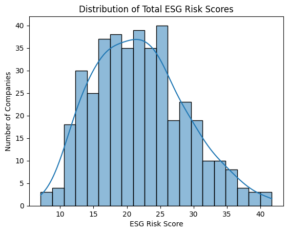

```python
sns.histplot(df['Total ESG Risk score'], bins=20, kde=True)
plt.title('Distribution of Total ESG Risk Scores')
plt.xlabel('ESG Risk Score')
plt.ylabel('Number of Companies')
plt.show()
```

This graph shows us the distribution of Total ESG Risk Scores among the S&P 500 companies. The somewhat bell-shaped curve suggets that most companies are distributed around 15-25 ESG risk, with a small subset of companies being low and high risk. Since the data isn't skewed heavily to one side, K-Means Means should be able to identify balanced clusters.

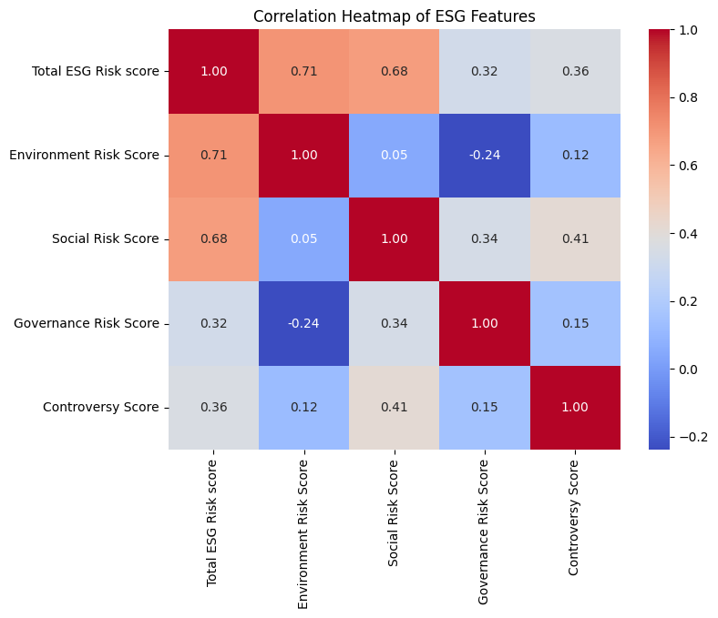

```python
esg_features = [
    'Total ESG Risk score',
    'Environment Risk Score',
    'Social Risk Score',
    'Governance Risk Score',
    'Controversy Score',
]

corr_matrix = df[esg_features].corr()

plt.figure(figsize=(8,6))
sns.heatmap(corr_matrix, annot=True, cmap='coolwarm', fmt=".2f")
plt.title('Correlation Heatmap of ESG Features')
plt.show()
```

## K-Means Model

Now that we have cleaned the data and explored some correlations using our data visualizations, we can start to build our model. For this experiment, I will use a K-Means clustering model.

### Selecting Features for Clustering

```python
from sklearn.preprocessing import StandardScaler
from sklearn.cluster import KMeans
from sklearn.decomposition import PCA

features = [
    'Environment Risk Score',
    'Social Risk Score',
    'Governance Risk Score',
    'Controversy Score',
]

X = df[features]
```

Since Total ESG Risk Score is strongly correlated with others, we can omit it to avoid redundancy.

### Elbow Method

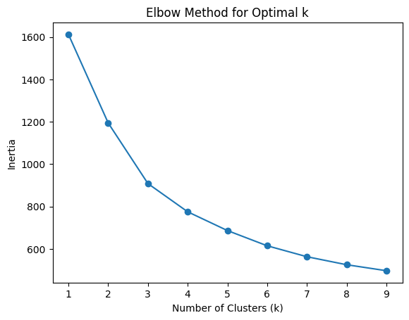

```python
scaler = StandardScaler()
X_scaled = scaler.fit_transform(X)

inertia = []
k_values = range(1, 10)

for k in k_values:
    kmeans = KMeans(n_clusters=k, random_state=42)
    kmeans.fit(X_scaled)
    inertia.append(kmeans.inertia_)

plt.plot(k_values, inertia, marker='o')
plt.xlabel('Number of Clusters (k)')
plt.ylabel('Inertia')
plt.title('Elbow Method for Optimal k')
plt.show()
```

Since K-Means is distance based, the features are scaled the same. The next block of code is the Elbow Method which helps decide how many ESG clusters to form. Looking at the graph, we can see the "elbow" point is at k=3 or k=4. For this project lets use k=3.

### Applying K-Means Clustering

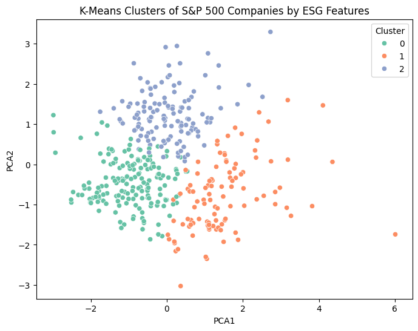

```
         Environment Risk Score  Social Risk Score  Governance Risk Score  \
Cluster
0                      3.297093           6.829070               5.855233
1                      2.637500          12.529808               9.500962
2                     11.780315           9.928346               5.926772

         Controversy Score
Cluster
0                 1.581395
1                 2.384615
2                 2.275591
Sector   Basic Materials  Communication Services  Consumer Cyclical  \
Cluster
0                      2                       5                 28
1                      1                       8                  7
2                     16                       1                 16

Sector   Consumer Defensive  Energy  Financial Services  Healthcare  \
Cluster
0                         5       1                  20          20
1                         3       0                  43          31
2                        25      19                   0           0

Sector   Industrials  Real Estate  Technology  Utilities
Cluster
0                 27           21          41          2
1                 10            0           1          0
2                 20            0           5         25
```

```python
kmeans = KMeans(n_clusters=3, random_state=42)
df['Cluster'] = kmeans.fit_predict(X_scaled)

pca = PCA(n_components=2)
pca_result = pca.fit_transform(X_scaled)

df['PCA1'] = pca_result[:, 0]
df['PCA2'] = pca_result[:, 1]

plt.figure(figsize=(8,6))
sns.scatterplot(data=df, x='PCA1', y='PCA2', hue='Cluster', palette='Set2')
plt.title('K-Means Clusters of S&P 500 Companies by ESG Features')
plt.show()

cluster_summary = df.groupby('Cluster')[features].mean()
print(cluster_summary)

sector_distribution = df.groupby(['Cluster', 'Sector']).size().unstack(fill_value=0)
print(sector_distribution)
```

Although this seems somewhat complicated, I will break down and summarize what this graph and output means. On the scatter plot, each point is a company and each color corresponds to a distinct ESG risk cluster. Cluster 0 (green) means low ESG risk / balanced companies. Cluster 1 (Orange) means governance and social risk companies. Cluster 2 (Blue) means high environmental risk companies.

Now to summarize the output:

- Cluster 0 contains sectors like Technology (41), Industrials (27), Healthcare (20), Financial Services (20)
  - Companies mostly focused on innovation or services with lower direct environmental footprint
- Cluster 1 contains sectors like Financial Services (43), Healthcare (31)
  - Financial firms and healthcare companies often criticized for governance or diversity issues despite low environmental risks
- Cluter 2 contains sectors like Energy (19), Consumer Defensive (25), Basic Materials (16), Utilities (25)
  - Resource-intensive sectors, which explains the High Environmental Risk

## Impact

This project aims to build a K-Means clustering model that groups S&P 500 comapnies / sectors based on their Environmental, Social, and Governance (ESG) performance. Understanding how these sectors and companies cluster according to ESG risk helps investors investors, policymakers, and analysts identify patterns across industries and make more informed decisions. However, there are potential social and ethical considerations that arise from this project. Relying solely on algorithmic clustering may oversimplify complex ESG behaviors or misclassify companies due to incomplete or outdated data. Therefore, these results should be used as a guiding analytical tool as the goal of this project is primarily educational and exploratory.

## Conclusion

By experimenting and understanding ESG features and clustering parameters, I learned that the choice of features and the number of clusters greatly influences how companies are grouped and interpreted. Overall, this project showed me the importance of exploring relationships and patterns rather than making exact predictions.

## References

[Project Files](https://github.com/spham64/esg_clustering) (GitHub)

[Kaggle Dataset](https://www.kaggle.com/datasets/pritish509/s-and-p-500-esg-risk-ratings)

[Visa](https://www.macrotrends.net/stocks/charts/V/visa/number-of-employees) - Employee Information

[RedMed](https://www.macrotrends.net/stocks/charts/RMD/resmed/number-of-employees) - Employee Information

[Netapp](https://www.macrotrends.net/stocks/charts/NTAP/netapp/number-of-employees) - Employee Information